# Unlocking the Potential of Allogeneic Vδ2 T Cells for Ovarian Cancer Therapy through CD16 Biomarker Selection and CAR/IL-15 Engineering

2022-08-15

Creator: Wenbin Guo < wbguo[AT]ucla[DOT]edu >

Description: this script is used to perform the following tasks in RNA-seq analysis  
- batch effects correction  
- PCA analysis  
- Differential gene expression analysis  
- DE gene Over-representation Enrichment analysis  
- Gene set enrichment analysis (GSEA)  
- single sample GSEA (ssGSEA)  
- data visualization such as heatmap, volcano plot, bar plot, etc.

Each tool’s version can be found in the `sessionInfo` section or from the original paper titled:  
> [Unlocking the Potential of Allogeneic Vδ2 T Cells for Ovarian Cancer Therapy through CD16 Biomarker Selection and CAR/IL-15 Engineering](https://www.nature.com/articles/s41467-023-42619-2)

Input file:  
- `DL_tables-PBMC_gdT-Sample.csv`: the metadata of samples  
- `raw_counts.txt`: gene expression raw counts matrix  
- `gene_info_full.rds`: provide mappings between gene_id and gene_name, it’s extracted from the GTF file  
- `DL_tables-ImmuneCellAI-signature_list_final.csv`: signature gene list for each cell type extracted from the `ImmuneCellAI` paper  
- `DL_tables-PBMC_gdT-Gene_list.csv`: gene list for heatmap  
- `DL_tables-GO_pathway_gene_annotate.csv`: gene list to be highlighted in the GSEA pathway results

Output file:  
- figures: check the `html` file  
- tables: check the `write results` section

The input files can be accessed/obtained from the following options:  
- [Github](https://github.com/wbvguo/Collaboratory/tree/main/Derek_Lee-Unlocking_potential_of_Allogeneic_gdT_cells_by_CD16_selection_and_CAR-IL15_engineering)  
- [Zenodo](https://zenodo.org/deposit/8072772#)  
- the author

# load

## package

```r
library(dplyr)
library(tidyr)
library(tidyverse)
library(tibble)
library(data.table)
```

```r
library(cowplot)
library(corrplot)
library(ggplot2)
library(ggpubr)
library(ggh4x)
library(ggrepel)
library(ggVennDiagram)
library(ggalluvial)
library(ggplotify)
library(UpSetR)
library(gridExtra)
library(patchwork)
library(viridis)
library(circlize)
library(RColorBrewer)

# BiocManager & Github
library(ComplexHeatmap)
library(edgeR)
library(DESeq2)
```

## function

```r
# make directory
make_dir = function(dir){
  if (! dir.exists(dir)){
    dir.create(dir, recursive = TRUE)
  }else{
    print(paste0(dir, " exists! Skip creating..."))
  }
}

# perform log10(x+1) transformation
library(magrittr)
```

```r
log2_transform = function(df, psuedo_count = 1){
  df_log = df %>%
    data.frame() %>%  lapply(function(x){log2(x+psuedo_count)}) %>% data.frame() %>%
    magrittr::set_rownames(rownames(df)) %>%
    magrittr::set_colnames(colnames(df))
  return(df_log)
}

# filter by gene expression, perform cpm and log10(cpm+1) transformation
process_countData_logCPM = function(count_df, group = NULL, min_count = 10, min_prop = 0.1){
  library(edgeR)
  if(is.null(group)){group = rep(1, ncol(count_df))}
  dge_count = DGEList(counts = count_df, group = group)
  dge_cpm   = cpm(dge_count)

  keep_idx  = filterByExpr(dge_count, min.count = min_count, min.prop = min_prop)
  dge_keep  = dge_count[keep_idx, ,keep.lib.sizes=FALSE]
  dge_keep  = calcNormFactors(dge_keep)

  dge_keep_cpm = cpm(dge_keep)
  dge_keep_cpm_log = log2_transform(dge_keep_cpm)
  return(list(dge_count= dge_count,
              dge_cpm  = dge_cpm,
              dge_keep = dge_keep,
              dge_keep_cpm = dge_keep_cpm,
              dge_keep_cpm_log = dge_keep_cpm_log))
}

# get the the var_gene_list and topN (or top percent) most variable genes
get_topN_var_mat = function(count_df, topN=NULL, prop = 0.2){
  var_genes_list = apply(count_df, MARGIN = 1, var)
  if(is.null(topN)){
    topN = round(nrow(count_df)*prop)
  }
  topN_genes = names(sort(var_genes_list, decreasing=TRUE))[1:topN]
  return(list(var_genes = var_genes_list,
              topN_mat  = count_df[topN_genes,] %>% as.matrix()))
}

# perform PCA
perform_PCA = function(count_mat, attr_df = NULL, axes = c(1, 2)){
  library(factoextra)
  pca_res = prcomp(t(count_mat), scale = TRUE, center = TRUE)
  pca_res_summary = summary(pca_res)

  plot_pca_res = fviz_pca_ind(pca_res, repel = TRUE, geom = "point", axes = axes)
  plot_pca_res$labels$x = str_replace(plot_pca_res$labels$x, pattern = "Dim", replacement = "PC")
  plot_pca_res$labels$y = str_replace(plot_pca_res$labels$y, pattern = "Dim", replacement = "PC")
  if(is.null(attr_df)){
    attr_df = sample_attr
  }
  plot_pca_res$data = dplyr::left_join(plot_pca_res$data, attr_df %>% dplyr::rename(name = Sample_id))

  return(list(pca_res = pca_res, pca_res_plot = plot_pca_res))
}

# adjust batch effects
adjust_batch = function(count_df, batch, group=NULL,covar_mod=NULL){
  library(sva)
  countData_adj = ComBat_seq(count_df %>% as.matrix(), batch=batch,
                             group=group, covar_mod = covar_mod)
  return(countData_adj)
}
```

## path

```r
project_path = "~/iproject/Cancer_immune"

data_path = paste0(project_path, "/data/")
save_path = data_path
bool_rerun = FALSE

# Input
gene_info_rds = paste0(data_path, "/gene_info_full.rds") # collected from annotation file gencode v32 gtf
countData_txt = paste0(data_path, "/raw_counts.txt")
countData_rds = paste0(data_path, "/countData.rds")
sig_gene_file2= paste0(data_path, "/DL_tables-ImmuneCellAI-signature_list_final.csv")
pbmc_sample_file = paste0(data_path, "/DL_tables-PBMC_gdT-Sample.csv")
htmap_gene_file  = paste0(data_path, "/DL_tables-PBMC_gdT-Gene_list.csv")
pathway_gene_annotate_file = paste0(data_path, "/DL_tables-GO_pathway_gene_annotate.csv")

# Color setting
color_list = setNames(c("#F1BB7B","#E06666", "#38B17D", "#7B7B7B"),
                      c("T","CD16_Low", "CD16_High", "NK-Act"))
color_list_gdT  = setNames(c("#E06666", "#38B17D"),
                           c("CD16_Low", "CD16_High"))
```

# read in

```r
# read in gene_info
gene_info_obj= readRDS(gene_info_rds)
gene_info    = gene_info_obj$gene_info_keep
gene_id_name = gene_info_obj$gene_id_name
gene_name_id = gene_info_obj$gene_name_id


# read in countData
if(bool_rerun){
  countData_all = read.table(countData_txt, sep = "\t",
                             header = TRUE, row.names = 1, check.names = FALSE)
  saveRDS(countData_all, countData_rds)
}else{
  countData_all = readRDS(countData_rds)
}

# read in meta data
pbmc_sample  = read.csv(pbmc_sample_file,sep = ",", header = TRUE) %>%
  dplyr::mutate(Sample_label = ifelse(CD16_flag == "", Sample_label, CD16_flag))


# filter lowly expressed genes (at least 10 counts in 2 samples)
min_count = 10
min_prop  = 0.1 # 20samples, this gives "at least 2 samples"

pbmc_count = countData_all[,pbmc_sample$Sample_id]
pbmc_countData = process_countData_logCPM(pbmc_count, min_count = min_count, min_prop = min_prop)
cat("\n")
```

```r
print(dim(pbmc_countData$dge_keep_cpm))
```

```
## [1] 14500    20
```

# PCA on batch corrected data

```r
pbmc_count_adj0 = adjust_batch(pbmc_count, batch = pbmc_sample$Batch, group = pbmc_sample$Cell_type)
```

```
## Found 3 batches
## Using full model in ComBat-seq.
## Adjusting for 2 covariate(s) or covariate level(s)
## Estimating dispersions
## Fitting the GLM model
## Shrinkage off - using GLM estimates for parameters
## Adjusting the data
```

```r
pbmc_countData_adj0 = process_countData_logCPM(pbmc_count_adj0, min_count = min_count, min_prop = min_prop)
cat("\n")
```

```r
print(dim(pbmc_countData_adj0$dge_keep_cpm))
```

```
## [1] 14457    20
```

```r
pbmc_topN_var_res_adj0 = get_topN_var_mat(pbmc_countData_adj0$dge_keep_cpm_log, topN = 500)
pbmc_pca_res_adj0 = perform_PCA(pbmc_topN_var_res_adj0$topN_mat, attr_df = pbmc_sample)
```

## PCA plots

```r
plot_pbmc_pca_res_adj0_color = pbmc_pca_res_adj0$pca_res_plot +
  geom_point(aes(color = Sample_label), size = 6) +
  scale_color_manual(name = "Sample_label", values= color_list) +
  theme(axis.line = element_line(linewidth = 0.5, linetype = "solid"),
        axis.title= element_text(size = 18),
        axis.text = element_text(size = 12),
        panel.background = element_rect(fill = NA),
        panel.grid.major = element_line(linetype = "blank"),
        panel.grid.minor = element_line(linetype = "blank"),
        strip.background = element_rect(fill = "white"),
        legend.title = element_text(face = "bold", color = NA),
        legend.background = element_rect(fill = NA, color = NA),
        legend.key = element_rect(fill = NA, color = NA),
        legend.text.align = 0,
        legend.position = "bottom",
        legend.justification = c(0.75,0),
        legend.direction = "horizontal",
        legend.text = element_text(margin = margin(0, 0, 0, 0, "pt"), size = 11),
        aspect.ratio=1) +
  labs(title = NULL, colour = NULL, fill = NULL, linetype = NULL, shape = NULL)


plot_pbmc_pca_res_adj0_label = pbmc_pca_res_adj0$pca_res_plot + geom_point(aes(color = Sample_label), size = 2) +
  ggrepel::geom_text_repel(aes(label = name), max.overlaps = 20) +
  scale_color_manual(name = "Sample_label", values= color_list) +
  theme(axis.line = element_line(linewidth = 0.5, linetype = "solid"),
        axis.title= element_text(size = 15),
        axis.text = element_text(size = 12),
        panel.background = element_rect(fill = NA),
        panel.grid.major = element_line(linetype = "blank"),
        panel.grid.minor = element_line(linetype = "blank"),
        strip.background = element_rect(fill = "white"),
        legend.title = element_text(face = "bold", color = NA),
        legend.background = element_rect(fill = NA, color = NA),
        legend.key = element_rect(fill = NA, color = NA),
        legend.text.align = 0,
        legend.position = "bottom",
        legend.justification = c(0.75,0),
        legend.direction = "horizontal",
        legend.text = element_text(margin = margin(0, 0, 0, 0, "pt"), size = 11),
        aspect.ratio=1) +
  labs(title = NULL, colour = NULL, fill = NULL, linetype = NULL, shape = NULL)
```

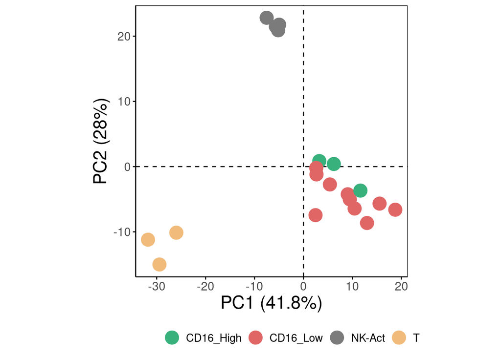

```r
plot_pbmc_pca_res_adj0_color
```

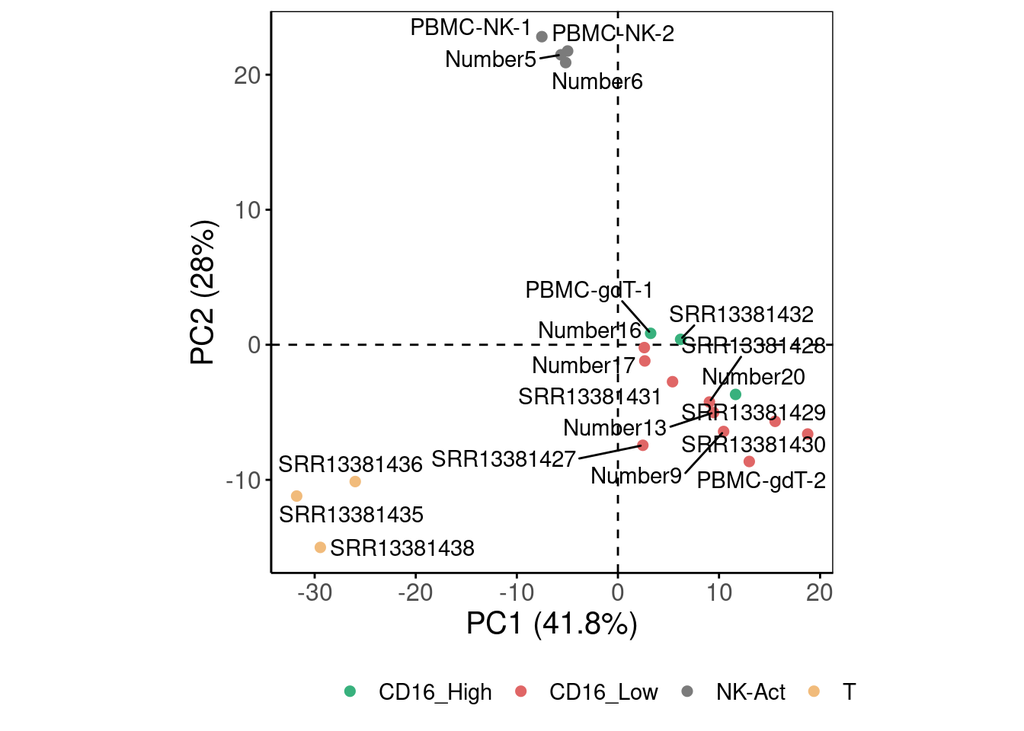

```r
plot_pbmc_pca_res_adj0_label
```

## PCA for gdT

```r
gdT_sample = pbmc_sample %>% dplyr::filter(Cell_type == "gdT")
gdT_topN_var_res_adj0 = get_topN_var_mat(pbmc_countData_adj0$dge_keep_cpm_log[gdT_sample$Sample_id], topN = 500)

gdT_pca_res_adj0= perform_PCA(gdT_topN_var_res_adj0$topN_mat, attr_df = gdT_sample)
```

```r
plot_gdT_pca_res_adj0_color = gdT_pca_res_adj0$pca_res_plot +
  geom_point(aes(color = Sample_label), size = 6) +
  scale_color_manual(name = "Sample_label", values= color_list_gdT) +
  theme(axis.line = element_line(linewidth = 0.5, linetype = "solid"),
        axis.title= element_text(size = 18),
        axis.text = element_text(size = 12),
        panel.background = element_rect(fill = NA),
        panel.grid.major = element_line(linetype = "blank"),
        panel.grid.minor = element_line(linetype = "blank"),
        strip.background = element_rect(fill = "white"),
        legend.title = element_text(face = "bold", color = NA),
        legend.background = element_rect(fill = NA, color = NA),
        legend.key = element_rect(fill = NA, color = NA),
        legend.text.align = 0,
        legend.position = "bottom",
        legend.justification = c(0.75,0),
        legend.direction = "horizontal",
        legend.text = element_text(margin = margin(0, 0, 0, 0, "pt"), size = 11),
        aspect.ratio=1) +
  labs(title = NULL, colour = NULL, fill = NULL, linetype = NULL, shape = NULL)


plot_gdT_pca_res_adj0_label = gdT_pca_res_adj0$pca_res_plot +
  geom_point(aes(color = Sample_label), size = 2) +
  ggrepel::geom_text_repel(aes(label = name), max.overlaps = 20) +
  scale_color_manual(name = "Sample_label", values= color_list_gdT) +
  theme(axis.line = element_line(linewidth = 0.5, linetype = "solid"),
        axis.title= element_text(size = 15),
        axis.text = element_text(size = 12),
        panel.background = element_rect(fill = NA),
        panel.grid.major = element_line(linetype = "blank"),
        panel.grid.minor = element_line(linetype = "blank"),
        strip.background = element_rect(fill = "white"),
        legend.title = element_text(face = "bold", color = NA),
        legend.background = element_rect(fill = NA, color = NA),
        legend.key = element_rect(fill = NA, color = NA),
        legend.text.align = 0,
        legend.position = "bottom",
        legend.justification = c(0.75,0),
        legend.direction = "horizontal",
        legend.text = element_text(margin = margin(0, 0, 0, 0, "pt"), size = 11),
        aspect.ratio=1) +
  labs(title = NULL, colour = NULL, fill = NULL, linetype = NULL, shape = NULL)
```

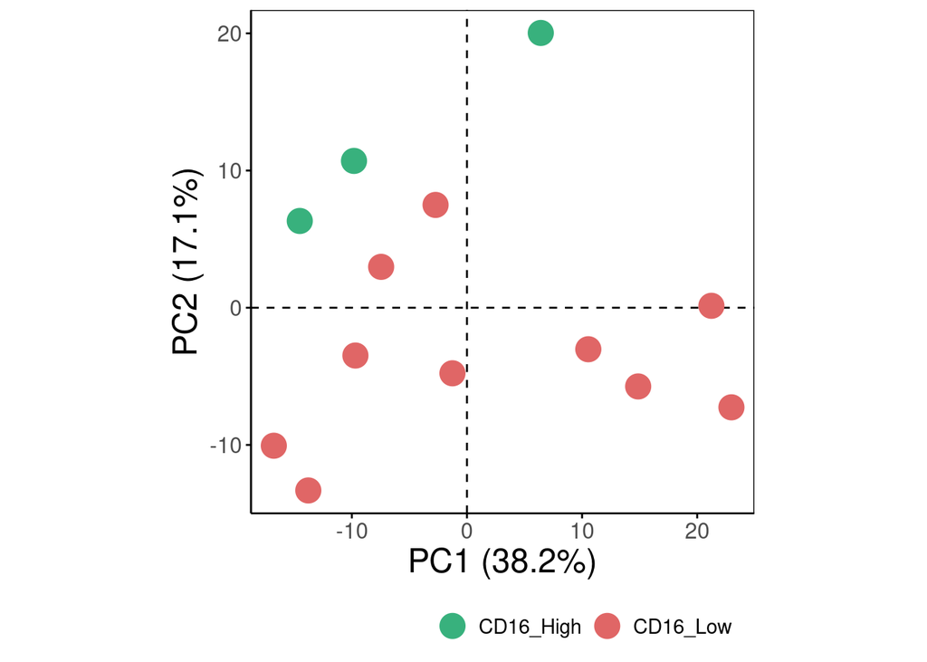

```r
plot_gdT_pca_res_adj0_color
```

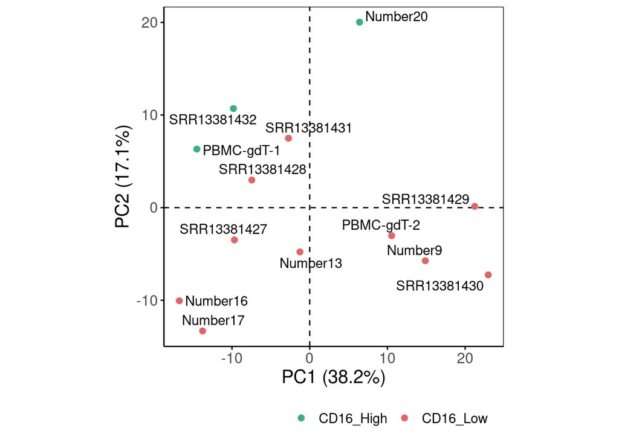

```r
plot_gdT_pca_res_adj0_label
```

# CD16 distribution

```r
pbmc_cd16_gene_name = "FCGR3A"

pbmc_cd16_gene_df = dplyr::left_join(pbmc_sample[,1:11],
                              pbmc_countData$dge_keep_cpm[gene_name_id[pbmc_cd16_gene_name],] %>%
                                as.data.frame() %>% set_colnames("CD16_unadjusted") %>% rownames_to_column("Sample_id"),
                              by = "Sample_id") %>%
  dplyr::left_join(pbmc_countData_adj0$dge_keep_cpm[gene_name_id[pbmc_cd16_gene_name],] %>%
              as.data.frame() %>% set_colnames("CD16") %>% rownames_to_column("Sample_id"),
            by = "Sample_id") %>%
  dplyr::mutate(Sample_label = factor(Sample_label, levels = c("T", "CD16_Low", "CD16_Med", "CD16_High", "NK-Act")))
```

## use kmeans to confirm the high/low group

```r
gdT_cd16_expr_vec = pbmc_cd16_gene_df %>% filter(Cell_type == "gdT") %>% pull(CD16, Sample_id)
kmeans(gdT_cd16_expr_vec, centers = 2)
```

```
## K-means clustering with 2 clusters of sizes 10, 3
##
## Cluster means:
##        [,1]
## 1  67.92234
## 2 324.89378
##
## Clustering vector:
##  PBMC-gdT-1  PBMC-gdT-2 SRR13381427 SRR13381428 SRR13381429 SRR13381430
##           2           1           1           1           1           1
## SRR13381431 SRR13381432     Number9    Number13    Number16    Number17
##           1           2           1           1           1           1
##    Number20
##           2
##
## Within cluster sum of squares by cluster:
## [1] 20347.853  1134.893
##  (between_SS / total_SS =  87.6 %)
##
## Available components:
##
## [1] "cluster"      "centers"      "totss"        "withinss"     "tot.withinss"
## [6] "betweenss"    "size"         "iter"         "ifault"
```

## plot

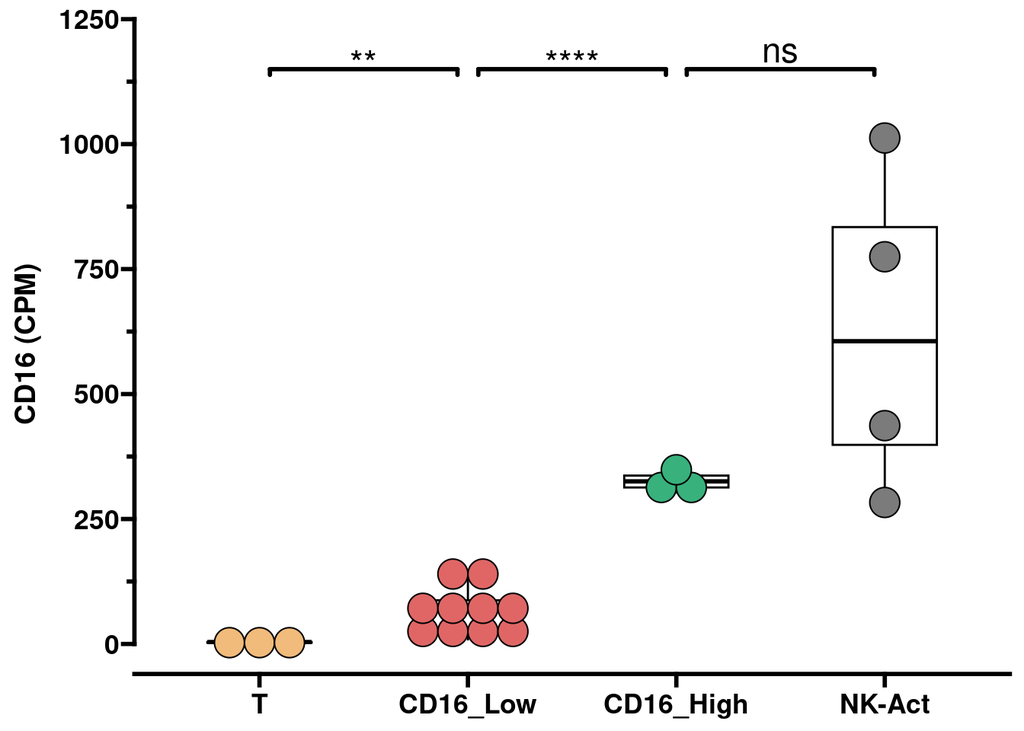

```r
library(ggprism)
my_comparison = list(c("T", "CD16_Low"),
                     c("CD16_Low", "CD16_High"),
                     c("CD16_High", "NK-Act"))

my_comparison_test = compare_means(CD16 ~ Sample_label, method = "t.test", data = pbmc_cd16_gene_df) %>%
  dplyr::filter(paste0(group1, ".vs.",group2) %in% sapply(my_comparison, FUN = function(x){paste0(x[1], ".vs.",x[2])})) %>%
  dplyr::mutate(y.position = c (1150, 1150,1150))

plot_cd16_boxplot = ggplot(pbmc_cd16_gene_df, aes(x = Sample_label, y = CD16)) +
  geom_boxplot(width = 0.5, colour = "black") +
  geom_dotplot(aes(fill = Sample_label), binaxis='y', dotsize = 1.5, stackdir='center', position=position_dodge(1)) +
  stat_pvalue_manual(my_comparison_test, label = "p.signif",
                     bracket.shorten = 0.1, bracket.size = 1, tip.length = 0.01, size = 6) +
  scale_y_continuous(limits = c(0, 1200)) +
  scale_color_prism("floral") +
  scale_fill_prism("floral") +
  scale_fill_manual(values = color_list) +
  guides(y = "prism_offset_minor") +
  theme_prism(base_size = 14) +
  theme(legend.position = "none")+
  labs(x = NULL) +
  ylab("CD16 (CPM)")
plot_cd16_boxplot
```

# Heatmap

```r
gene_interest_full= read.csv(htmap_gene_file, sep = ",", header = TRUE) %>%
  dplyr::left_join(gene_info, by = "gene_name") %>%
  dplyr::mutate(category = factor(category,
                           levels = c("Transcription factor", "Cytotoxicity", "NK activating", "NK inhibition",
                                      "Inhibitory marker", "T-costimulatory", "Inflammatory homing")))
gene_interest_refine = gene_interest_full %>% dplyr::filter(gene_id %in% rownames(pbmc_countData_adj0$dge_keep_cpm))
gene_id_interest = gene_interest_refine %>% dplyr::select(gene_id) %>% na.omit() %>% unlist() %>% unname()

sample_id_order  = pbmc_cd16_gene_df %>% group_by(Cell_type) %>%
  dplyr::mutate(Cell_type = factor(Cell_type, levels = c("NK_Act", "gdT", "T"))) %>%
  dplyr::arrange(desc(CD16), .by_group = TRUE) %>% pull(Sample_id)
sample_id_order_gdT = pbmc_cd16_gene_df %>%
  dplyr::filter(Cell_type == "gdT") %>%
  dplyr::arrange(desc(CD16)) %>% pull(Sample_id)
sample_id_order_gdT_plot = sample_id_order_gdT[c(1:3,4:13)]

get_heatmap_mat = function(heatmap_df){
  heatmap_df_std = heatmap_df %>% t() %>% scale() %>% as.data.frame() %>% t()
  rownames(heatmap_df_std) = gene_id_name[rownames(heatmap_df_std)]
  return(heatmap_df_std)
}
```

## all samples

```r
df_interest_gene = pbmc_countData_adj0$dge_keep_cpm_log[gene_id_interest, sample_id_order]
df_interest_genes_std = get_heatmap_mat(df_interest_gene)
print(range(df_interest_genes_std))
```

```
## [1] -2.944911  2.610373
```

```r
col_scale= c(-3, 0, 3)
col_fun  = colorRamp2(col_scale, hcl_palette = "RdBu", reverse = T)

df_cd16_std = pbmc_countData_adj0$dge_keep_cpm_log[gene_name_id[pbmc_cd16_gene_name],sample_id_order] %>%
  t() %>% scale() %>% as.data.frame() %>% as.matrix() %>% set_colnames("CD16")

ha_cd16  = HeatmapAnnotation(CD16_expr_z = df_cd16_std,
                             col = list(CD16_expr_z = col_fun), show_legend = FALSE)

ht_marker = Heatmap(df_interest_genes_std %>% as.matrix(),
                    cluster_rows = FALSE,
                    cluster_columns = FALSE,
                    show_row_dend = FALSE,
                    show_column_dend = FALSE,
                    show_row_names = TRUE,
                    show_column_names = TRUE,
                    column_names_side = "top",
                    use_raster = FALSE,
                    col = col_fun,
                    row_title_rot = 0,
                    row_split = gene_interest_refine$category,
                    #column_split = gene_interest$category,
                    heatmap_legend_param = list(title = "z-score",
                                                at = col_scale),
                    width = ncol(df_interest_genes_std)*unit(5, "mm"),
                    height = nrow(df_interest_genes_std)*unit(5, "mm"),
                    top_annotation = ha_cd16)
```

## gdT only

```r
df_interest_gene_gdT = pbmc_countData_adj0$dge_keep_cpm_log[gene_id_interest, sample_id_order_gdT_plot]
df_interest_genes_gdT_std = get_heatmap_mat(df_interest_gene_gdT)
print(range(df_interest_genes_gdT_std))
```

```
## [1] -2.801772  2.854306
```

```r
col_scale_gdT = c(-3, 0, 3)
col_fun_gdT   = colorRamp2(col_scale_gdT, hcl_palette = "RdBu", reverse = T)


df_cd16_std_gdT = pbmc_countData_adj0$dge_keep_cpm_log[gene_name_id[pbmc_cd16_gene_name],sample_id_order_gdT_plot] %>%
  t() %>% scale() %>% as.data.frame() %>% as.matrix() %>% set_colnames("CD16")

ha_cd16_gdT = HeatmapAnnotation(CD16_expr_z = df_cd16_std_gdT,
                                col = list(CD16_expr_z = col_fun_gdT), show_legend = FALSE)

ht_marker_gdT = Heatmap(df_interest_genes_gdT_std %>% as.matrix(),
                        cluster_rows = TRUE,
                        cluster_columns = FALSE,
                        show_row_dend = FALSE,
                        show_column_dend = FALSE,
                        show_row_names = TRUE,
                        show_column_names = TRUE,
                        column_names_side = "top",
                        use_raster = FALSE,
                        col = col_fun_gdT,
                        row_title_rot = 0,
                        row_split = gene_interest_refine$category,
                        #column_split = gene_interest$category,
                        heatmap_legend_param = list(title = "z-score",
                                                    at = col_scale_gdT),
                        width = ncol(df_interest_genes_gdT_std)*unit(5, "mm"),
                        height = nrow(df_interest_genes_gdT_std)*unit(5, "mm"),
                        top_annotation = ha_cd16_gdT)
```

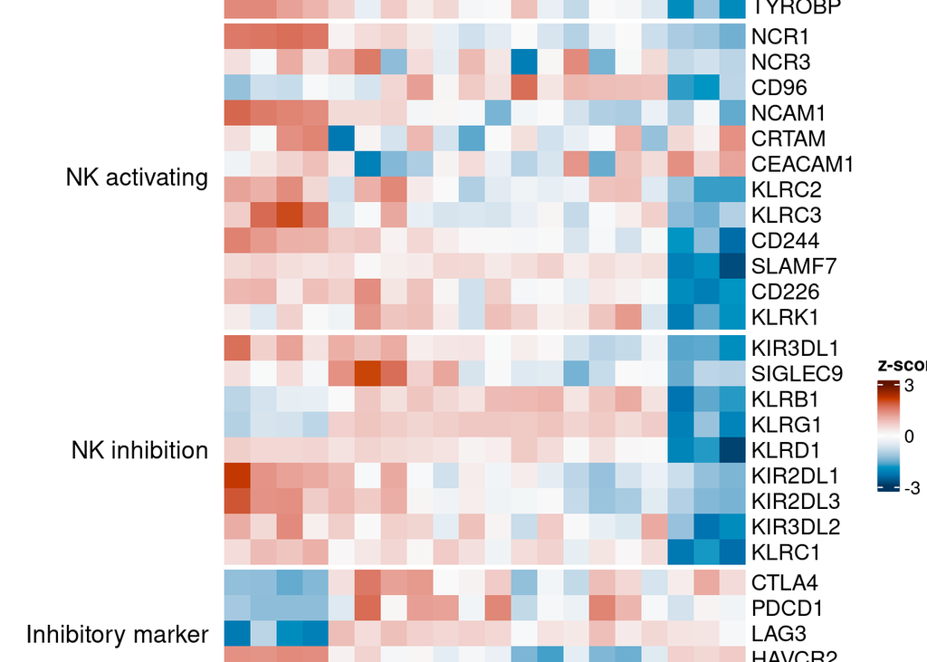

```r
draw(ht_marker)
```

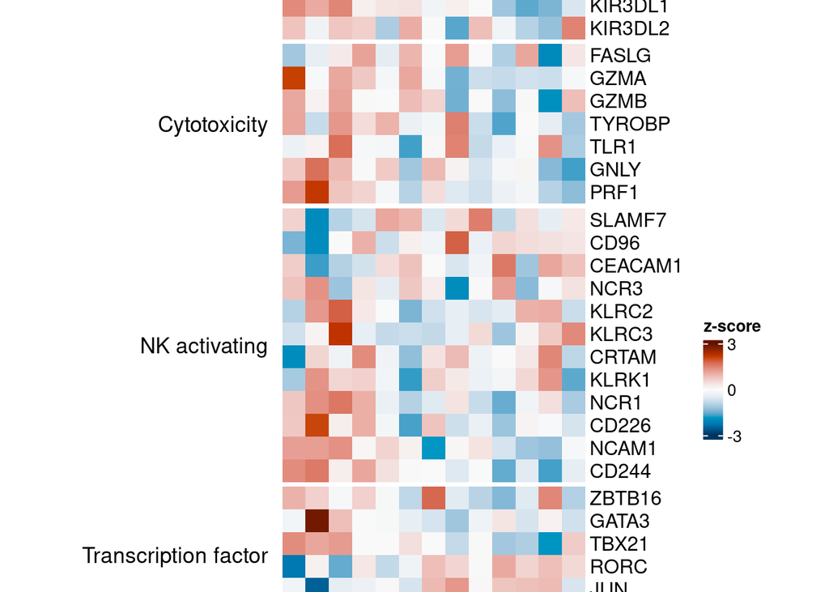

```r
draw(ht_marker_gdT)
```

# DE analysis continous (with CD16 expr)

```r
perform_DE_DESeq2_cont  = function(dge_obj, covar_df){
  dds = DESeqDataSetFromMatrix(countData = dge_obj$counts,
                               colData   = cbind(dge_obj$samples, covar_df),
                               design    = ~ CD16_logCPM)
  dds = DESeq(dds)
  res = results(dds) %>% as.data.frame()

  DE_gene_list = res %>% dplyr::filter(padj < 0.05) %>% rownames()
  return(list(res = res, DE_gene_list = DE_gene_list, dge_obj = dds))
}
```

## run test

```r
count_keep_gdT      = pbmc_countData_adj0$dge_count$counts[, gdT_sample$Sample_id]
countData_trans_gdT = process_countData_logCPM(count_df = count_keep_gdT, min_count = 10, min_prop = 0.5)
covar_df_gdT = countData_trans_gdT$dge_keep$samples %>% rownames_to_column("Sample_id") %>%
  left_join(pbmc_cd16_gene_df, by = "Sample_id") %>%
  column_to_rownames("Sample_id") %>%
  dplyr::mutate(Intercept = 1, CD16_logCPM = log2(CD16 +1)) %>%
  mutate_at(c('CD16_logCPM'), ~(scale(.) %>% as.vector)) %>%
  select(Intercept, CD16_logCPM)

countData_trans_gdT$covar_df = covar_df_gdT

DE_deseq2_cont= perform_DE_DESeq2_cont(countData_trans_gdT$dge_keep, countData_trans_gdT$covar_df)
# just a message: https://support.bioconductor.org/p/104097/
```

## volcano plot

```r
library(EnhancedVolcano)
get_valcano_plot = function(df, plot_title, thre_pval, thre_logFC,
                            ylim_vec = c(-0.5, 3), xlim_vec = c(-10,10)){
  valcano_plot= EnhancedVolcano(df, lab = gene_id_name[rownames(df)],
                                x = "log2FoldChange", y = "padj",
                                xlab = bquote(~Log[2] ~ "fold change"),
                                ylab = bquote(~-Log[10] ~ italic("adjusted P-value")),
                                pCutoff = thre_pval,
                                FCcutoff =thre_logFC, # Cut-off for absolute log2 fold-change
                                pointSize = 1,
                                labSize = 4,
                                legendLabSize = 10,
                                title = plot_title,
                                subtitle = NULL,
                                xlim = xlim_vec,
                                ylim = ylim_vec,
                                drawConnectors = TRUE,
                                arrowheads = FALSE,
                                legendLabels = c("NS", expression(Log[2] ~ FC), "adjusted P-value",
                                                 expression("adjusted P-value" ~ and ~ log[2] ~ FC)),
                                caption = NULL)
  valcano_plot= valcano_plot + theme(plot.title = element_text(hjust = 0.5))
  return(valcano_plot)
}
```

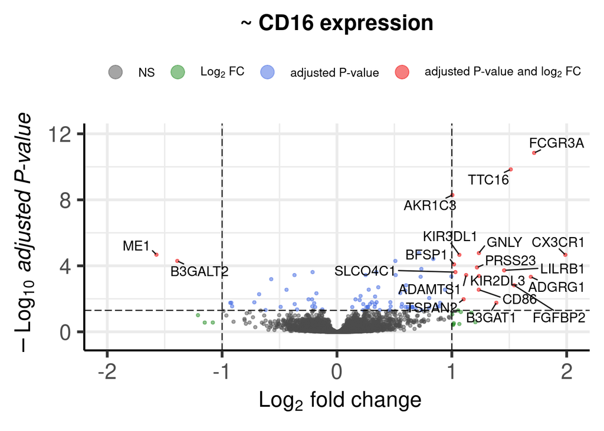

```r
thre_pval = 0.05
thre_logFC= 1
plot_valcano_deseq2_cont= get_valcano_plot(DE_deseq2_cont$res,  "~ CD16 expression",
                                           thre_pval, thre_logFC, ylim_vec = c(-0.5, 12),xlim_vec = c(-2,2))
plot_valcano_deseq2_cont
```

```r
DE_deseq2_cont$res = DE_deseq2_cont$res %>%
  mutate_at(c("pvalue"), ~replace(., . == 0, min(.[.>0], na.rm = TRUE)/10))
## Converting the zero p-values to 10^-1 * current lowest non-zero p-value, for example CD16
```

# Enrichment analysis

```r
library(org.Hs.eg.db)
library(msigdbr)
library(clusterProfiler)
```

```r
library(enrichplot)
library(GseaVis)


get_sorted_list = function(res, method = "edgeR/DESeq2", key_type = "ENSEMBL"){
  if (method == "clipper"){
    sorted_list = res %>% rownames_to_column("gene_id")  %>% pull(contrast_score, gene_id) %>% sort(decreasing = TRUE)
  } else{
    sorted_list = res %>% mutate(score = sign(log2FoldChange) * -1 * log10(pvalue)) %>%
      rownames_to_column("gene_id")  %>% pull(score, gene_id) %>% sort(decreasing = TRUE)
  }
  if(key_type == "SYMBOL"){
    sorted_list = setNames(unname(sorted_list), gene_id_name[names(sorted_list)])
  }

  return(sorted_list)
}


get_gsea_result = function(sorted_DE_list, ont_type, key_type = "ENSEMBL", p_val_cut = 0.05){
  gsea_res = gseGO(geneList= sorted_DE_list,
                   ont = ont_type,
                   keyType = key_type,
                   minGSSize = 3,
                   maxGSSize = 800,
                   pvalueCutoff = p_val_cut,
                   eps = 0,
                   seed = TRUE,
                   verbose = TRUE,
                   OrgDb =  org.Hs.eg.db,
                   pAdjustMethod = "BH")
  return(gsea_res)
}

get_enrichGO_result = function(gene_list, ont_type, key_type = "ENSEMBL", p_val_cut = 0.05){
  ego_res = enrichGO(gene          = gene_list,
                     OrgDb         = org.Hs.eg.db,
                     keyType       = key_type,
                     ont           = ont_type,
                     pAdjustMethod = "BH",
                     pvalueCutoff  = 0.05,
                     qvalueCutoff  = 0.05)
  return(ego_res)
}

convert_enrich_id_name = function(enrich_obj, method = "gsea"){
  if(method == "gsea"){
    obj = enrich_obj
    obj@result$core_enrichment = sapply(obj@result$core_enrichment,
                                        FUN = function(x){paste(gene_id_name[unlist(strsplit(x, "/"))], collapse = "/")})
    obj@geneList = setNames(unname(obj@geneList), unname(gene_id_name[names(obj@geneList)]))
  }else{
    obj = enrich_obj
    obj@result$geneID = sapply(obj@result$geneID,
                               FUN = function(x){paste(gene_id_name[unlist(strsplit(x, "/"))], collapse = "/")})
    obj@gene = unname(gene_id_name[obj@gene])
    obj@universe = unname(gene_id_name[obj@universe])
  }
  return(obj)
}
```

## DE over-representation analysis

```r
ont_type = "BP"
ego_obj_deseq2_cont= get_enrichGO_result(DE_deseq2_cont$res %>% dplyr::filter(padj < 0.05) %>% rownames(), ont_type)
```

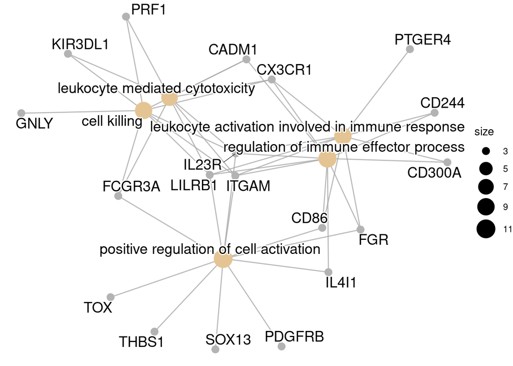

```r
ego_obj_deseq2_cont2 = get_enrichGO_result(gene_id_name[DE_deseq2_cont$res %>% dplyr::filter(padj < 0.05) %>% rownames()],
                                           key_type = "SYMBOL", ont_type)
plot_ego_deseq2_cnet = cnetplot(ego_obj_deseq2_cont2)
plot_ego_deseq2_cnet
```

## GSEA

```r
ont_type = "BP"
gsea_obj_deseq2_cont = get_gsea_result(get_sorted_list(DE_deseq2_cont$res), ont_type)
```

```
## preparing geneSet collections...
```

```
## GSEA analysis...
```

```
## leading edge analysis...
```

```
## done...
```

```r
plot_gsea_deseq2_cont = dotplot(gsea_obj_deseq2_cont, title = "Deseq2 (cont)",showCategory=30, split=".sign", label_format =60) +
  facet_grid(.~.sign) +
  theme(plot.title = element_text(hjust = 0.5),
        axis.text.y= element_text(size = 11))
```

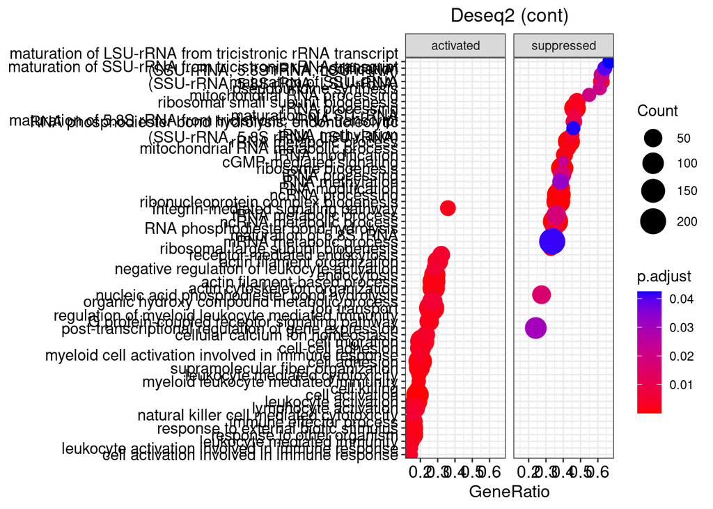

```r
plot_gsea_deseq2_cont
```

## plot pathway

```r
gsea_obj_deseq2_cont2 = get_gsea_result(get_sorted_list(DE_deseq2_cont$res, key_type = "SYMBOL"),
                                        ont_type, key_type = "SYMBOL")
```

```
## preparing geneSet collections...
```

```
## GSEA analysis...
```

```
## leading edge analysis...
```

```
## done...
```

```r
gsea_annotate_genes = read.table(pathway_gene_annotate_file, sep = ",", header = TRUE)
```

```r
pathway_cytotoxity = "GO:0001909"
pathway_phagocytosis = "GO:0006909"
pathway_degranulation = "GO:0043299"
pathway_proliferation = "GO:0046651"
pathway_fc_gamma = "GO:0038094"


plot_es_cytotoxity    = gseaNb(object = gsea_obj_deseq2_cont2,
                               geneSetID = pathway_cytotoxity,
                               addGene = gsea_annotate_genes %>%
                                 dplyr::filter(ID == pathway_cytotoxity) %>%
                                 select(gene_name) %>% deframe(),
                               subPlot = 2, termWidth = 60,
                               addPval = T,
                               pvalX = 0.65,pvalY = 0.65,
                               pCol = 'black',
                               pHjust = 0)

plot_es_degranulation = gseaNb(object = gsea_obj_deseq2_cont2,
                               geneSetID = pathway_degranulation,
                               addGene = gsea_annotate_genes %>%
                                 dplyr::filter(ID == pathway_degranulation) %>%
                                 select(gene_name) %>% deframe(),
                               subPlot = 2, termWidth = 60,
                               addPval = T,
                               pvalX = 0.65,pvalY = 0.65,
                               pCol = 'black',
                               pHjust = 0)

plot_es_proliferation = gseaNb(object = gsea_obj_deseq2_cont2,
                               geneSetID = pathway_proliferation,
                               addGene = gsea_annotate_genes %>%
                                 dplyr::filter(ID == pathway_proliferation) %>%
                                 select(gene_name) %>% deframe(),
                               subPlot = 2, termWidth = 60,
                               addPval = T,
                               pvalX = 0.65,pvalY = 0.65,
                               pCol = 'black',
                               pHjust = 0)

plot_es_fc_gamma      = gseaNb(object = gsea_obj_deseq2_cont2,
                               geneSetID = pathway_fc_gamma,
                               addGene = gsea_annotate_genes %>%
                                 dplyr::filter(ID == pathway_fc_gamma) %>%
                                 select(gene_name) %>% deframe(),
                               subPlot = 2, termWidth = 60,
                               addPval = T,
                               pvalX = 0.65,pvalY = 0.65,
                               pCol = 'black',
                               pHjust = 0)

plot_es_phagocytosis  = gseaNb(object = gsea_obj_deseq2_cont2,
                               geneSetID = pathway_phagocytosis,
                               addGene = gsea_annotate_genes %>%
                                 dplyr::filter(ID == pathway_phagocytosis) %>%
                                 select(gene_name) %>% deframe(),
                               subPlot = 2, termWidth = 60,
                               addPval = T,
                               pvalX = 0.65,pvalY = 0.65,
                               pCol = 'black',
                               pHjust = 0)
```

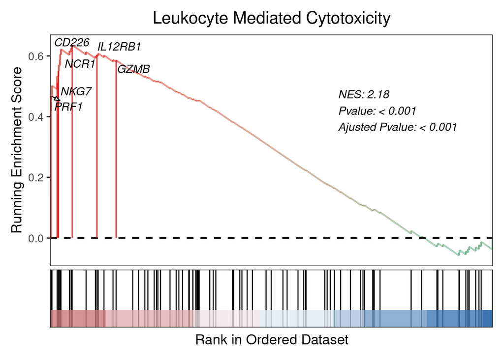

```r
plot(plot_es_cytotoxity)
```

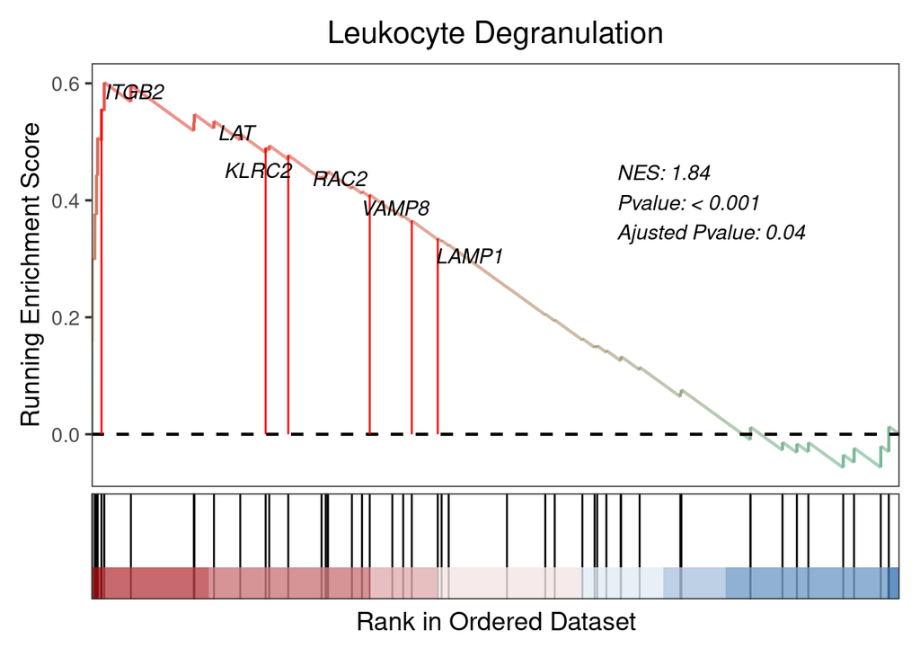

```r
plot(plot_es_degranulation)
```

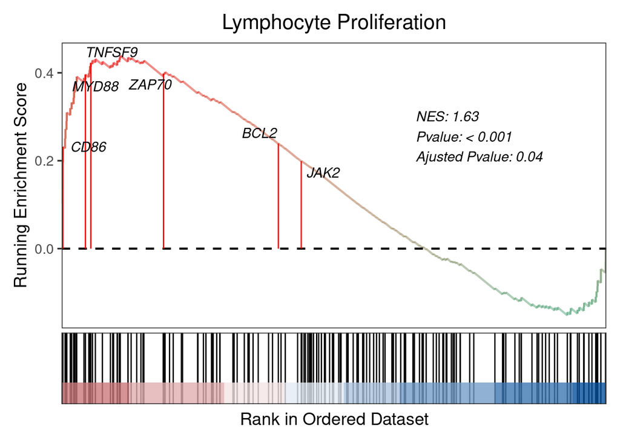

```r
plot(plot_es_proliferation)
```

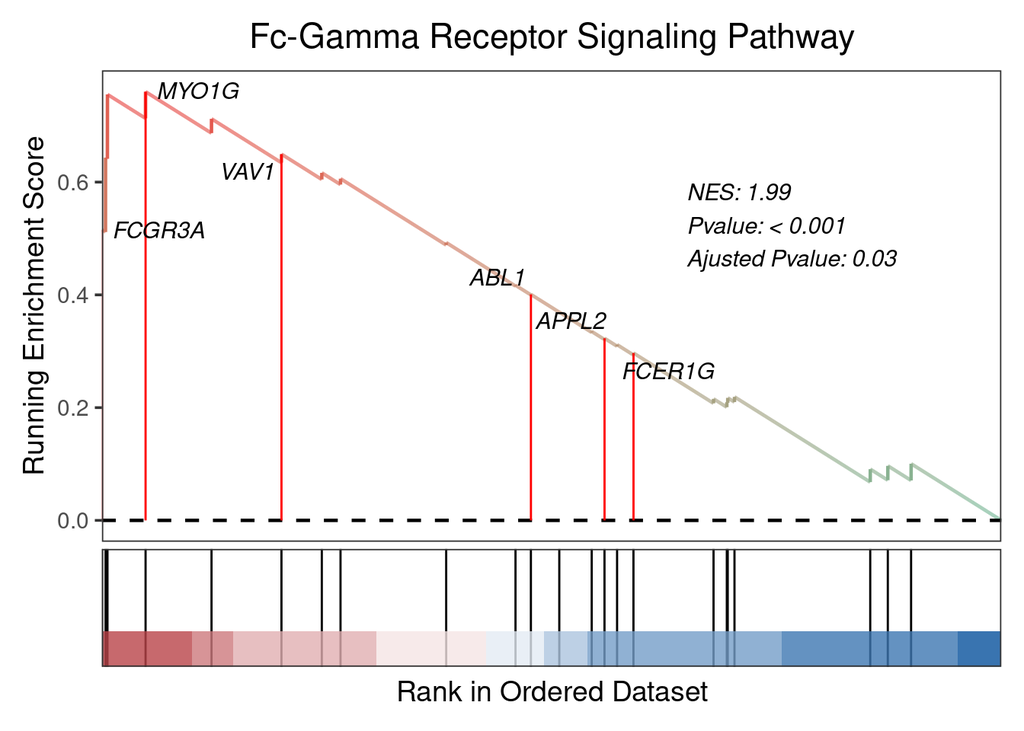

```r
plot(plot_es_fc_gamma)
```

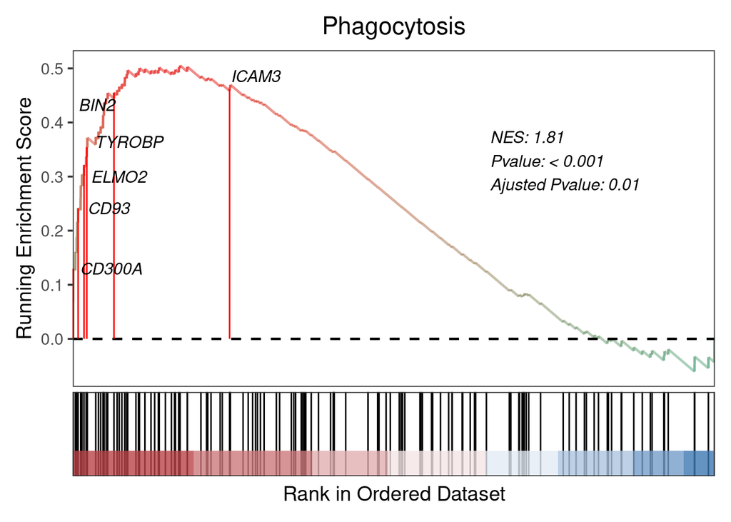

```r
plot(plot_es_phagocytosis)
```

# ssGSEA

```r
library(readxl)
library(tidyverse)
library(dplyr)
library(GSVA)
library(ggtern)
library(ggforce)
```

## ImmuneCellAI signature

```r
library(RecordLinkage)
closestMatch = function(string, stringVector){
  distance = levenshteinSim(string, stringVector);
  return(list(stringVector[distance==max(distance)], which(distance==max(distance))))
}

sig_gene_df2 = read.table(sig_gene_file2, sep = ",", header = TRUE) %>%
  gather() %>%
  dplyr::rename(cell_type = key, gene_name = value) %>%
  dplyr::filter(gene_name != "")


for(i in seq(nrow(sig_gene_df2))){
  gene_name = sig_gene_df2[i, "gene_name"] %>% unlist() %>% trimws()
  match_info= closestMatch(gene_name, gene_info$gene_name)
  match_name= match_info[[1]]
  match_idx = match_info[[2]]
  if(length(match_name)== 1){
    sig_gene_df2[i, c("match_name", "gene_id")] = gene_info[match_idx, c("gene_name", "gene_id")]
  }else{
    best_guess = sapply(match_name, FUN = function(x){grepl(x, gene_name, fixed = TRUE)})
    if(sum(best_guess) == 1){
      print(paste0(gene_name, ":", paste(match_name, collapse = " "), ":", match_name[best_guess]))
      sig_gene_df2[i, c("match_name", "gene_id")] = gene_info[match_idx[best_guess], c("gene_name", "gene_id")]
    }else{
      print(paste0(gene_name, ":", paste(match_name, sep = " ")))
    }
  }
}
```

```
## [1] "DFNB31:DTNBP1" "DFNB31:IFNB1"  "DFNB31:DFFBP1" "DFNB31:FNBP1"
## [5] "DFNB31:EFNB3"  "DFNB31:EFNB1"
## [1] "GGT1:GGT1" "GGT1:GGT1"
```

```r
sig_gene_df2[sig_gene_df2$gene_name == "DFNB31", c("match_name", "gene_id")] = c("WHRN", gene_name_id["WHRN"])
sig_gene_df2[sig_gene_df2$gene_name == "GGT1", c("match_name", "gene_id")] = c("GGT1", "ENSG00000100031")
```

```r
marker_list2 = split(sig_gene_df2$gene_id, sig_gene_df2$cell_type)

gsva_res2 = gsva(pbmc_countData_adj0$dge_keep_cpm[,sample_id_order], marker_list2, verbose=FALSE, method="ssgsea")%>%
  t() %>% as.data.frame() %>% rownames_to_column("Sample_id") %>%
  left_join(pbmc_cd16_gene_df, by = "Sample_id") %>%
  column_to_rownames("Sample_id")
```

```
## [1] "Calculating ranks..."
## [1] "Calculating absolute values from ranks..."
## [1] "Normalizing..."
```

## corrplot for all cell types and gdT samples

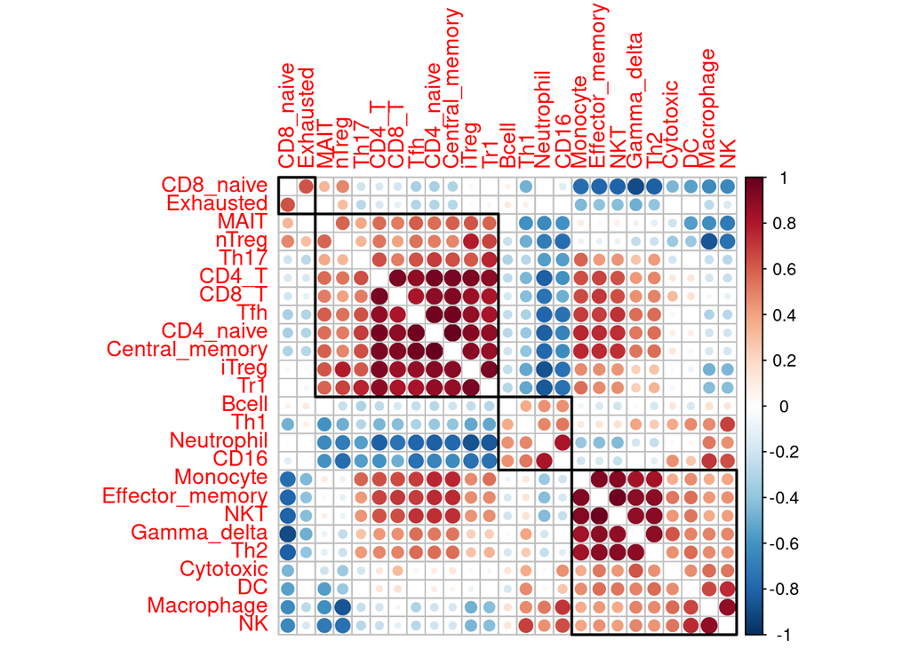

```r
cor_immune_cell_mat = cor(gsva_res2[,c(1:24, 36)])
cor_immune_cell_mat_gdT = cor(gsva_res2[sample_id_order_gdT,c(1:24, 36)])

corrplot(cor_immune_cell_mat,
         order = "hclust", diag = FALSE, addrect = 4,
         col = rev(COL2('RdBu')))
```

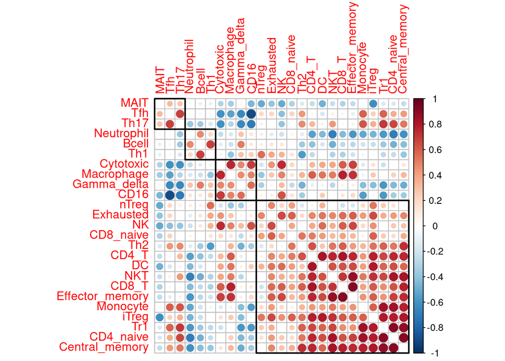

```r
corrplot(cor_immune_cell_mat_gdT,
         order = "hclust", diag = FALSE, addrect = 4,
         col = rev(COL2('RdBu')))
```

# write results

```r
write.table(pbmc_countData_adj0$dge_count$counts %>% as.data.frame() %>%
              rownames_to_column("gene_id"),
            file = paste0(save_path, "raw_counts_batch_adjusted.txt"),
            sep = "\t", quote = FALSE, row.names = FALSE, col.names = TRUE)

write.table(pbmc_countData_adj0$dge_keep_cpm %>% as.data.frame() %>%
              rownames_to_column("gene_id"),
            file = paste0(save_path, "dge_keep_cpm_batch_adjusted.tsv"),
            sep = "\t", quote = FALSE, row.names = FALSE, col.names = TRUE)

write.table(DE_deseq2_cont$res %>%
              slice_min(pvalue, n = nrow(DE_deseq2_cont$res)) %>%
              rownames_to_column("gene_id") %>%
              mutate(gene_name = gene_id_name[gene_id], .after = gene_id),
            file = paste0(save_path, "DESeq2_diff_expr_results.tsv"),
            sep = "\t", quote = FALSE, row.names = FALSE, col.names = TRUE)

write.table(ego_obj_deseq2_cont2@result,
            file = paste0(save_path, "Over-representation_GOBP_results.tsv"),
            sep = "\t", quote = FALSE, row.names = FALSE, col.names = TRUE)

write.table(gsea_obj_deseq2_cont@result,
        file = paste0(save_path, "GSEA_GOBP_deseq2_cont.tsv"),
        sep = "\t", quote = FALSE, row.names = FALSE, col.names = TRUE)
```

[session information not shown]